# Анализ временных рядов

Данный notebook содержит анализ влияния стационарности и стратегий прогнозирования на качество предсказаний цен акций Apple (AAPL) за период 2010-2020.

## Гипотеза 1: Приведение данных к стационарным улучшает прогноз

## Гипотеза 2: Периодическое переобучеие даёт лучшие результаты, чем прямое прогнозирование.

Устанавливаем библиотеку yfinance для загрузки финансовых данных

```python
import sys
!{sys.executable} -m pip install yfinance
```

Импортируем все необходимые библиотеки для анализа временных рядов

```python
import yfinance as yf
import pandas as pd
import numpy as np
import matplotlib.pyplot as plt
import seaborn as sns
from scipy import stats
from datetime import datetime, timedelta
from statsmodels.tsa.seasonal import seasonal_decompose
from statsmodels.graphics.tsaplots import plot_acf, plot_pacf
from statsmodels.tsa.stattools import adfuller, kpss
from statsmodels.tsa.holtwinters import SimpleExpSmoothing, ExponentialSmoothing
from sklearn.metrics import mean_absolute_error, mean_squared_error
import time
import warnings
warnings.filterwarnings('ignore')

print("Библиотеки загружены успешно")
```

```
Библиотеки загружены успешно
```

Загружаем исторические данные цен акций Apple за 10 лет

```python
ticker_symbol = "AAPL"
data = yf.download(ticker_symbol, start="2010-01-01", end="2020-01-01")
print(f"Данные загружены: {len(data)} наблюдений")
```

```
[*********************100%***********************]  1 of 1 completed
```

```
Данные загружены: 2516 наблюдений
```

Извлекаем цены закрытия, заполянем пропуски методом forward fill

```python
prices = data['Close'].ffill()
prices.name = 'prices'

print(f"Загружено {len(prices)} наблюдений")
print(f"Период: с {prices.index[0].date()} по {prices.index[-1].date()}")
print(f"Пропусков в данных: {prices.isna().sum()}")
```

```
Загружено 2516 наблюдений
Период: с 2010-01-04 по 2019-12-31
Пропусков в данных: Ticker
AAPL    0
dtype: int64
```

Строим график цен закртия акций во времени

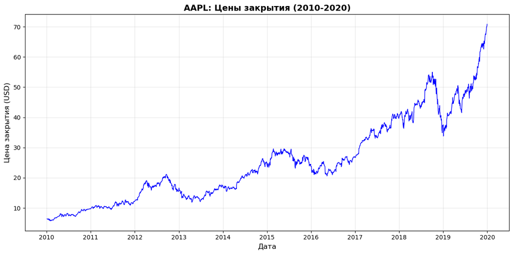

```python
plt.figure(figsize=(12, 6))
plt.plot(prices.index, prices, linewidth=1, color='blue')
plt.title(f"{ticker_symbol}: Цены закрытия (2010-2020)", fontsize=14, fontweight='bold')
plt.xlabel("Дата", fontsize=12)
plt.ylabel("Цена закрытия (USD)", fontsize=12)
plt.grid(True, alpha=0.3)
plt.tight_layout()
plt.show()
```

Разбиваем ряд на тренд, сезонность и остатки (мультипликативная модель)

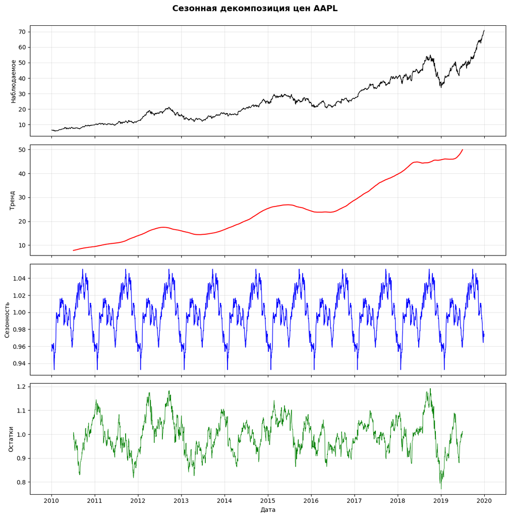

```python
result = seasonal_decompose(prices, model='multiplicative', period=252)

fig, axes = plt.subplots(4, 1, figsize=(12, 12), sharex=True)

axes[0].plot(prices.index, result.observed, color='black', linewidth=1)
axes[0].set_ylabel('Наблюдаемое')
axes[0].grid(True, alpha=0.3)

axes[1].plot(prices.index, result.trend, color='red', linewidth=1.5)
axes[1].set_ylabel('Тренд')
axes[1].grid(True, alpha=0.3)

axes[2].plot(prices.index, result.seasonal, color='blue', linewidth=1)
axes[2].set_ylabel('Сезонность')
axes[2].grid(True, alpha=0.3)

axes[3].plot(prices.index, result.resid, color='green', linewidth=0.7)
axes[3].set_ylabel('Остатки')
axes[3].set_xlabel('Дата')
axes[3].grid(True, alpha=0.3)

plt.suptitle(f'Сезонная декомпозиция цен {ticker_symbol}', fontsize=14, fontweight='bold', y=1.00)
plt.tight_layout()
plt.show()
```

Реализуем функцию для проверки стационарности с помощью ADF и KPSS тестов

```python
def check_stationary(timeseries):

    timeseries_name = timeseries.name if timeseries.name else 'Series'
    timeseries = timeseries.dropna()

    # ADF тест (H0: ряд нестационарен)
    adf_result = adfuller(timeseries, autolag='AIC')
    adf_pvalue = adf_result[1]

    print('Результаты теста Дики-Фуллера (ADF):')
    print(f'  Статистика теста: {adf_result[0]:.4f}')
    print(f'  p-значение: {adf_pvalue:.4f}')

    if adf_pvalue < 0.05:
        print(f'Ряд {timeseries_name} СТАЦИОНАРЕН (отвергаем H0 при alpha=0.05)')
    else:
        print(f'Ряд {timeseries_name} НЕСТАЦИОНАРЕН (не отвергаем H0 при alpha=0.05)')

    # KPSS тест (H0: ряд стационарен)
    kpss_result = kpss(timeseries, regression='c', nlags="auto")
    kpss_pvalue = kpss_result[1]

    print('\nРезультаты теста KPSS:')
    print(f'  Статистика теста: {kpss_result[0]:.4f}')
    print(f'  p-значение: {kpss_pvalue:.4f}')

    if kpss_pvalue < 0.05:
        print(f'Ряд {timeseries_name} НЕСТАЦИОНАРЕН (отвергаем H0 при alpha=0.05)')
    else:
        print(f'Ряд {timeseries_name} СТАЦИОНАРЕН (не отвергаем H0 при alpha=0.05)')
```

Применим её к исходному ряду

```python
print("Проверка стационарности исходных цен:")

check_stationary(prices)
```

```
Проверка стационарности исходных цен:
Результаты теста Дики-Фуллера (ADF):
  Статистика теста: 1.4931
  p-значение: 0.9975
Ряд prices НЕСТАЦИОНАРЕН (не отвергаем H0 при alpha=0.05)

Результаты теста KPSS:
  Статистика теста: 7.2505
  p-значение: 0.0100
Ряд prices НЕСТАЦИОНАРЕН (отвергаем H0 при alpha=0.05)
```

Создадим функцию, которая остроит графики автокрреляции и частичной автокорреляционной функции

```python
def plot_acf_pacf(timeseries, title="ACF/PACF", lags=40):

    clean_series = timeseries.dropna()

    fig, axes = plt.subplots(1, 2, figsize=(12, 5))

    plot_acf(clean_series, ax=axes[0], lags=lags)
    axes[0].set_title('ACF (Автокорреляционная функция)', fontsize=11)
    axes[0].grid(True, alpha=0.3)

    plot_pacf(clean_series, ax=axes[1], lags=lags, method='ywm')
    axes[1].set_title('PACF (Частичная автокорреляция)', fontsize=11)
    axes[1].grid(True, alpha=0.3)

    plt.suptitle(title, fontsize=13, fontweight='bold')
    plt.tight_layout()
    plt.show()
```

Строим графики ACF и PACF для исходных цен

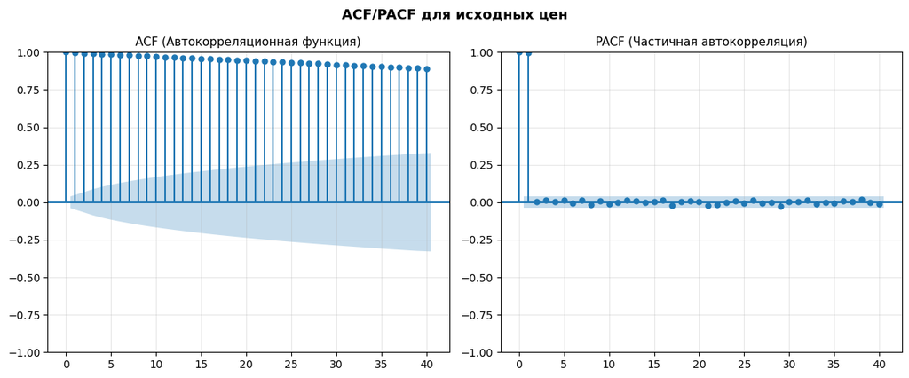

```python
plot_acf_pacf(prices, title='ACF/PACF для исходных цен', lags=40)
```

Применяем логарифмирование и первую разность для получения стационарного ряда

```python
# Логарифмирование делается стабилизации волатильности
# Первая разность логарифмов = логарифмическая доходность
log_returns = np.log(prices).diff().dropna()
log_returns.name = 'log_returns'

print(f"Исходный ряд: {len(prices)} наблюдений")

print(f"Логарифмические доходности: {len(log_returns)} наблюдений")
```

```
Исходный ряд: 2516 наблюдений
Логарифмические доходности: 2515 наблюдений
```

Проверим стационарность ряда лог-доходностей, а также построим для него ACF и PACF

```
Проверка стационарности логарифмов цен:
Результаты теста Дики-Фуллера (ADF):
  Статистика теста: -12.8523
  p-значение: 0.0000
Ряд log_returns СТАЦИОНАРЕН (отвергаем H0 при alpha=0.05)

Результаты теста KPSS:
  Статистика теста: 0.0635
  p-значение: 0.1000
Ряд log_returns СТАЦИОНАРЕН (не отвергаем H0 при alpha=0.05)
```

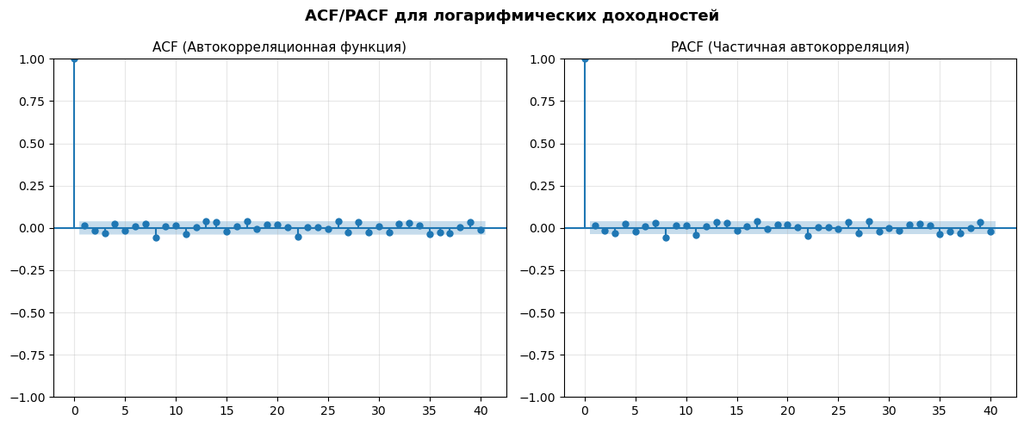

```python
print("Проверка стационарности логарифмов цен:")
check_stationary(log_returns)
plot_acf_pacf(log_returns, title="ACF/PACF для логарифмических доходностей", lags=40)
```

Визуализируем наш стационарный ряд

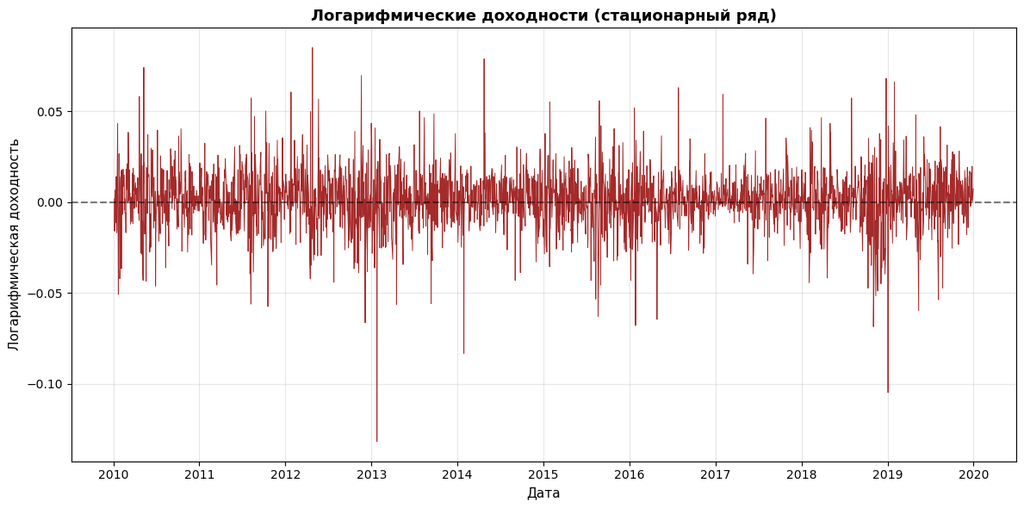

```python
plt.figure(figsize=(12, 6))
plt.plot(log_returns.index, log_returns, label='log_returns', color='brown', linewidth=0.7)
plt.title('Логарифмические доходности (стационарный ряд)', fontsize=13, fontweight='bold')
plt.xlabel("Дата", fontsize=11)
plt.ylabel("Логарифмическая доходность", fontsize=11)
plt.axhline(y=0, color='black', linestyle='--', alpha=0.5)
plt.grid(True, alpha=0.3)
plt.tight_layout()
plt.show()
```

Разделим данные на train и test

Первые 80% возьмём для обучения, оставшиеся 20% для тестирования и расчёта метрик

```python
# Нестационарные данные (исходные цены)
train_size_nonstationary = int(len(prices) * 0.8)
train_nonstationary = prices.iloc[:train_size_nonstationary]
test_nonstationary = prices.iloc[train_size_nonstationary:]

# Стационарные данные (логарифмические доходности)
train_size_stationary = int(len(log_returns) * 0.8)
train_stationary = log_returns.iloc[:train_size_stationary]
test_stationary = log_returns.iloc[train_size_stationary:]

# Для корректного сравнения убираем первое наблюдение из test_nonstationary
test_nonstationary_aligned = test_nonstationary.iloc[1:]

print(f"Нестационарные данные:")
print(f"  Train: {len(train_nonstationary)} наблюдений")
print(f"  Test: {len(test_nonstationary)} наблюдений")
print(f"  Test (aligned): {len(test_nonstationary_aligned)} наблюдений")

print(f"\nСтационарные данные:")
print(f"  Train: {len(train_stationary)} наблюдений")
print(f"  Test: {len(test_stationary)} наблюдений")
```

```
Нестационарные данные:
  Train: 2012 наблюдений
  Test: 504 наблюдений
  Test (aligned): 503 наблюдений

Стационарные данные:
  Train: 2012 наблюдений
  Test: 503 наблюдений
```

Визуализируем полученное разбиение

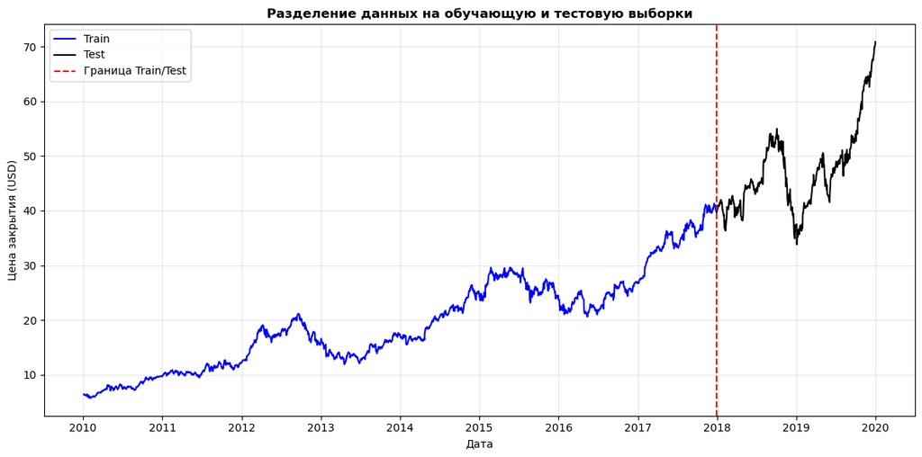

```python
plt.figure(figsize=(12, 6))
plt.plot(train_nonstationary.index, train_nonstationary, label='Train', color='blue')
plt.plot(test_nonstationary.index, test_nonstationary, label='Test', color='black')
plt.axvline(train_nonstationary.index[-1], color='red', linestyle='--', label='Граница Train/Test')
plt.title('Разделение данных на обучающую и тестовую выборки', fontweight='bold')
plt.xlabel("Дата")
plt.ylabel("Цена закрытия (USD)")
plt.legend(fontsize=10)
plt.grid(True, alpha=0.3)
plt.tight_layout()
plt.show()
```

## Гипотеза 1: Влияние стационарности на качество прогноза

Baseline модель (naive forecast)

```python
naive_value = float(train_nonstationary.iloc[-1])
naive_pred = pd.Series([naive_value] * len(test_nonstationary),
                       index=test_nonstationary.index)
naive_pred.name = 'Naive'

print(f"Naive прогноз: все {len(naive_pred)} значений равны {naive_value:.2f} USD")
```

```
Naive прогноз: все 504 значений равны 40.07 USD
```

Обучаем модель SES на нестационарных и стационарных данных

```python
# SES на нестационарных данных
ses_model_nonstat = SimpleExpSmoothing(train_nonstationary).fit(optimized=True)
ses_pred_nonstat = ses_model_nonstat.forecast(len(test_nonstationary))
ses_pred_nonstat.name = 'SES nonstat'

print(f"SES (нестационарные): alpha = {ses_model_nonstat.params['smoothing_level']:.4f}")

# SES на стационарных данных
ses_model_stat = SimpleExpSmoothing(train_stationary).fit(optimized=True)
ses_pred_stat = ses_model_stat.forecast(len(test_stationary))
ses_pred_stat.name = 'SES stat'

print(f"SES (стационарные): alpha = {ses_model_stat.params['smoothing_level']:.4f}")
```

```
SES (нестационарные): alpha = 1.0000
SES (стационарные): alpha = 0.0010
```

Обучаем модель Holt с учетом линейного тренда

```python
# Holt на нестационарных данных
holt_model_nonstat = ExponentialSmoothing(train_nonstationary, trend='add', seasonal=None).fit(optimized=True)
holt_pred_nonstat = holt_model_nonstat.forecast(len(test_nonstationary))
holt_pred_nonstat.name = 'Holt nonstat'

print(f"Holt (нестационарные): alpha = {holt_model_nonstat.params['smoothing_level']:.4f}, "
      f"beta = {holt_model_nonstat.params['smoothing_trend']:.4f}")

# Holt на стационарных данных
holt_model_stat = ExponentialSmoothing(train_stationary, trend='add', seasonal=None).fit(optimized=True)
holt_pred_stat = holt_model_stat.forecast(len(test_stationary))
holt_pred_stat.name = 'Holt stat'

print(f"Holt (стационарные): alpha = {holt_model_stat.params['smoothing_level']:.4f}, "
      f"beta = {holt_model_stat.params['smoothing_trend']:.4f}")
```

```
Holt (нестационарные): alpha = 1.0000, beta = 0.0000
Holt (стационарные): alpha = 0.0000, beta = 0.0000
```

Обучаем модель Holt-Winters

```python
# Holt-Winters на нестационарных данных
hw_model_nonstat = ExponentialSmoothing(train_nonstationary, trend='mul', seasonal=None).fit(optimized=True)
hw_pred_nonstat = hw_model_nonstat.forecast(len(test_nonstationary))
hw_pred_nonstat.name = 'Holt-Winters nonstat'

print(f"Holt-Winters (нестационарные): alpha = {hw_model_nonstat.params['smoothing_level']:.4f}")

# Holt-Winters на стационарных данных
hw_model_stat = ExponentialSmoothing(train_stationary).fit(optimized=True)
hw_pred_stat = hw_model_stat.forecast(len(test_stationary))
hw_pred_stat.name = 'Holt-Winters stat'

print(f"Holt-Winters (стационарные): alpha = {hw_model_stat.params['smoothing_level']:.4f}")
```

```
Holt-Winters (нестационарные): alpha = 1.0000
Holt-Winters (стационарные): alpha = 0.0000
```

Зададим функцию восстановления цен из лог-доходностей

```python
def restore_prices_from_log_returns(log_returns_series, initial_price):

    # Извлекаем скалярное значение если передан Series
    if isinstance(initial_price, (pd.Series, pd.DataFrame)):
        initial_price_value = float(initial_price.iloc[0])
    else:
        initial_price_value = float(initial_price)

    # Заполняем NaN нулями и вычисляем кумулятивную сумму
    log_returns_clean = log_returns_series.fillna(0)
    accumulated_log_returns = log_returns_clean.cumsum()

    # Восстанавливаем цены: P_t = P_0 * exp(sum(r_i))
    restored_prices = initial_price_value * np.exp(accumulated_log_returns)

    return restored_prices
```

Применяем эту функцию для восстановления цен всех моделей, обученных на стационарных данных

```python
# Восстанавливаем цены из прогнозов логарифмических доходностей
restore_prices_ses = restore_prices_from_log_returns(ses_pred_stat, train_nonstationary.iloc[-1])
restore_prices_ses.name = 'SES Stationary'

restore_prices_holt = restore_prices_from_log_returns(holt_pred_stat, train_nonstationary.iloc[-1])
restore_prices_holt.name = 'Holt Stationary'

restore_prices_hw = restore_prices_from_log_returns(hw_pred_stat, train_nonstationary.iloc[-1])
restore_prices_hw.name = 'Holt-Winters Stationary'

# Проверка корректности
print("Проверка восстановленных прогнозов:")
print(f"SES: {restore_prices_ses.isna().sum()} NaN, длина: {len(restore_prices_ses)}, "
      f"диапазон: [{restore_prices_ses.min():.2f}, {restore_prices_ses.max():.2f}]")
print(f"Holt: {restore_prices_holt.isna().sum()} NaN, длина: {len(restore_prices_holt)}, "
      f"диапазон: [{restore_prices_holt.min():.2f}, {restore_prices_holt.max():.2f}]")
print(f"HW: {restore_prices_hw.isna().sum()} NaN, длина: {len(restore_prices_hw)}, "
      f"диапазон: [{restore_prices_hw.min():.2f}, {restore_prices_hw.max():.2f}]")
```

```
Проверка восстановленных прогнозов:
SES: 0 NaN, длина: 503, диапазон: [40.10, 65.59]
Holt: 0 NaN, длина: 503, диапазон: [40.09, 52.51]
HW: 0 NaN, длина: 503, диапазон: [40.10, 63.16]
```

Приведём все прогнозы к единым индексам (из-за разной длины индексы разные)

```python
target_index = test_stationary.index

# Нестационарные прогнозы
naive_pred.index = test_nonstationary.index
ses_pred_nonstat.index = test_nonstationary.index
holt_pred_nonstat.index = test_nonstationary.index
hw_pred_nonstat.index = test_nonstationary.index

# Стационарные прогнозы (восстановленные)
restore_prices_ses.index = target_index
restore_prices_holt.index = target_index
restore_prices_hw.index = target_index

# Реальные значения для сравнения
test_nonstationary_aligned = test_nonstationary.iloc[1:]

print(f"Все прогнозы приведены к единому индексу: {len(target_index)} наблюдений")
```

```
Все прогнозы приведены к единому индексу: 503 наблюдений
```

Визуально сравним прогнозы на нестационарных и на стаицонарных данных

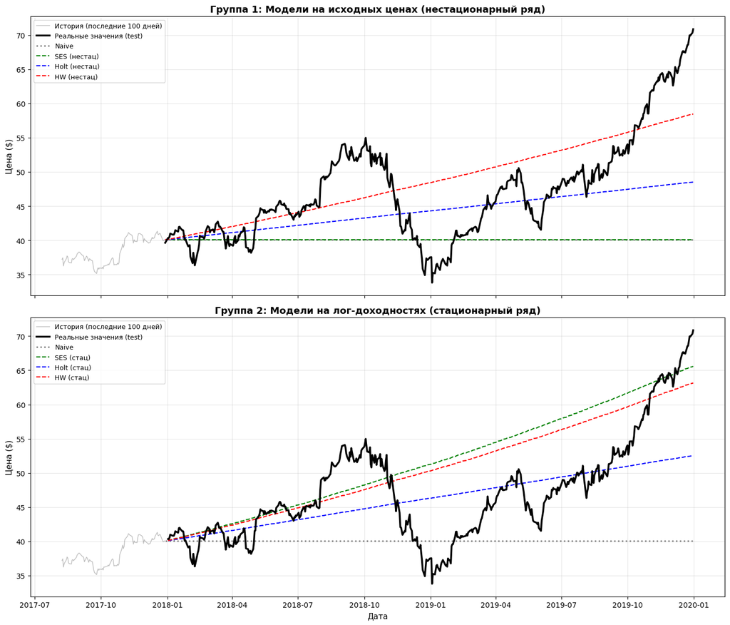

```python
fig, axes = plt.subplots(2, 1, figsize=(14, 12), sharex=True)

# График 1: Модели на нестационарных данных
axes[0].plot(train_nonstationary.index[-100:], train_nonstationary.iloc[-100:],
             color='gray', alpha=0.5, label='История (последние 100 дней)', linewidth=1)
axes[0].plot(test_nonstationary.index, test_nonstationary,
             color='black', linewidth=2.5, label='Реальные значения (test)', zorder=5)

axes[0].plot(naive_pred.index, naive_pred,
             label='Naive', linestyle=':', color='gray', linewidth=2)
axes[0].plot(ses_pred_nonstat.index, ses_pred_nonstat,
             label='SES (нестац)', linestyle='--', color='green', linewidth=1.5)
axes[0].plot(holt_pred_nonstat.index, holt_pred_nonstat,
             label='Holt (нестац)', linestyle='--', color='blue', linewidth=1.5)
axes[0].plot(hw_pred_nonstat.index, hw_pred_nonstat,
             label='HW (нестац)', linestyle='--', color='red', linewidth=1.5)

axes[0].set_title('Группа 1: Модели на исходных ценах (нестационарный ряд)',
                  fontsize=13, fontweight='bold')
axes[0].legend(loc='upper left', fontsize=9)
axes[0].grid(True, alpha=0.3)
axes[0].set_ylabel('Цена ($)', fontsize=11)

# График 2: Модели на стационарных данных
axes[1].plot(train_nonstationary.index[-100:], train_nonstationary.iloc[-100:],
             color='gray', alpha=0.5, label='История (последние 100 дней)', linewidth=1)
axes[1].plot(test_nonstationary_aligned.index, test_nonstationary_aligned,
             color='black', linewidth=2.5, label='Реальные значения (test)', zorder=5)

axes[1].plot(naive_pred.index, naive_pred,
             label='Naive', linestyle=':', color='gray', linewidth=2)
axes[1].plot(restore_prices_ses.index, restore_prices_ses,
             label='SES (стац)', linestyle='--', color='green', linewidth=1.5)
axes[1].plot(restore_prices_holt.index, restore_prices_holt,
             label='Holt (стац)', linestyle='--', color='blue', linewidth=1.5)
axes[1].plot(restore_prices_hw.index, restore_prices_hw,
             label='HW (стац)', linestyle='--', color='red', linewidth=1.5)

axes[1].set_title('Группа 2: Модели на лог-доходностях (стационарный ряд)',
                  fontsize=13, fontweight='bold')
axes[1].legend(loc='upper left', fontsize=9)
axes[1].grid(True, alpha=0.3)
axes[1].set_xlabel('Дата', fontsize=11)
axes[1].set_ylabel('Цена ($)', fontsize=11)

plt.tight_layout()
plt.show()
```

Запишем функцию, которая позволит рассчитывать метрики качества

Метрику DA решено не считать, т.к. модели по сути ловят только тренд (так мы задали их параметры) поэтому у всех прогнозом будет то, что цена все 503 дня прогнозов растёт, а значит считать метрику, которая бы показывала как точно угадываются движения рынка особого смысла нет (у всех моделей DA будет одинаковой, кроме разве что SES (non-stat))

```python
def calculate_metrics(y_true, y_pred, model_name):
    y_true_values = np.asarray(y_true).flatten()
    y_pred_values = np.asarray(y_pred).flatten()

    mae = np.mean(np.abs(y_true_values - y_pred_values))
    rmse = np.sqrt(np.mean((y_true_values - y_pred_values) ** 2))
    mape = np.mean(np.abs((y_true_values - y_pred_values) / y_true_values)) * 100

    return {
        'Model': model_name,
        'MAE': mae,
        'RMSE': rmse,
        'MAPE': mape
    }
```

Теперь рассчитаем метрики для всех наших моделей, запишем их в таблицу

```python
results = []

# Нестационарные модели
results.append(calculate_metrics(test_nonstationary, naive_pred, 'Naive'))
results.append(calculate_metrics(test_nonstationary, ses_pred_nonstat, 'SES (Нестац)'))
results.append(calculate_metrics(test_nonstationary, holt_pred_nonstat, 'Holt (Нестац)'))
results.append(calculate_metrics(test_nonstationary, hw_pred_nonstat, 'Holt-Winters (Нестац)'))

# Стационарные модели (восстановленные)
results.append(calculate_metrics(test_nonstationary_aligned, restore_prices_ses, 'SES (Стац)'))
results.append(calculate_metrics(test_nonstationary_aligned, restore_prices_holt, 'Holt (Стац)'))
results.append(calculate_metrics(test_nonstationary_aligned, restore_prices_hw, 'Holt-Winters (Стац)'))

# Создаем таблицу результатов
results_df = pd.DataFrame(results)

print("\n" + "=" * 70)
print("ТАБЛИЦА МЕТРИК КАЧЕСТВА ПРОГНОЗА (ГИПОТЕЗА 1)")
print("=" * 70)
print(results_df.to_string(index=False))
print("=" * 70)
```

```
======================================================================
ТАБЛИЦА МЕТРИК КАЧЕСТВА ПРОГНОЗА (ГИПОТЕЗА 1)
======================================================================
                Model      MAE      RMSE      MAPE
                Naive 7.778209 10.362531 14.852147
         SES (Нестац) 7.778209 10.362531 14.852147
        Holt (Нестац) 4.952924  6.801911  9.749431
Holt-Winters (Нестац) 4.591515  5.662002  9.968676
           SES (Стац) 5.833016  7.431664 13.026864
          Holt (Стац) 4.316301  5.829222  8.883631
  Holt-Winters (Стац) 5.325432  6.659052 11.836583
======================================================================
```

Визуализиурем полученные данные, для лучшего их понимания

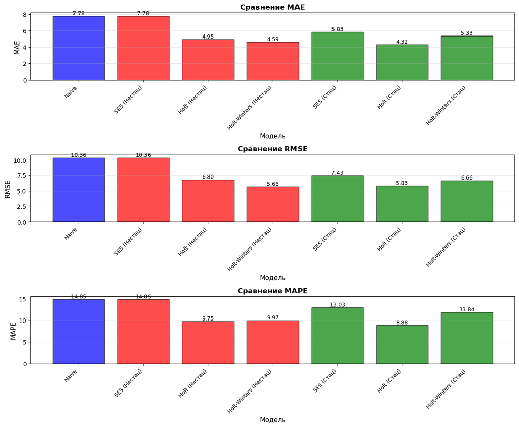

```python
fig, axes = plt.subplots(3, 1, figsize=(12, 10))

metrics = ['MAE', 'RMSE', 'MAPE']
colors = ['blue', 'red', 'red', 'red', 'green', 'green', 'green']

for idx, metric in enumerate(metrics):
    ax = axes[idx]
    x = np.arange(len(results_df))
    bars = ax.bar(x, results_df[metric], color=colors, alpha=0.7, edgecolor='black', linewidth=1)

    # Добавляем значения над столбцами
    for bar in bars:
        height = bar.get_height()
        ax.text(bar.get_x() + bar.get_width()/2., height,
                f'{height:.2f}',
                ha='center', va='bottom', fontsize=9)

    ax.set_xlabel('Модель', fontsize=11)
    ax.set_ylabel(metric, fontsize=11)
    ax.set_title(f'Сравнение {metric}', fontsize=12, fontweight='bold')
    ax.set_xticks(x)
    ax.set_xticklabels(results_df['Model'], rotation=45, ha='right', fontsize=9)
    ax.grid(True, alpha=0.3, axis='y')

plt.tight_layout()
plt.show()
```

Для того чтобы обоснованно говорить насколько прогнозы моделей различны, а результаты одной хуже/лучше другой нужно провести статистический тест.

DM-тест: H_0 модели обладают одинаковой точностью H_1 модели имеют разную точность

```python
def diebold_mariano_test(y_true, y_pred1, y_pred2):

    y_true = np.asarray(y_true).flatten()
    y_pred1 = np.asarray(y_pred1).flatten()
    y_pred2 = np.asarray(y_pred2).flatten()

    # Абсолютные ошибки
    e1 = np.abs(y_true - y_pred1)
    e2 = np.abs(y_true - y_pred2)

    # Разность потерь
    d = e1 - e2

    # DM статистика
    dm_stat = np.mean(d) / np.sqrt(np.var(d) / len(d))

    # p-value (двусторонний тест)
    p_value = 2 * (1 - stats.norm.cdf(np.abs(dm_stat)))

    return dm_stat, p_value
```

Для начала определим лучшие модели по метрике MAE (она наиболее легко интерпретируемая) среди моделей основанных на стационарных данных и на нестационарных

```python
# Разделяем модели на группы
nonstat_mask = results_df['Model'].str.contains('Нестац', regex=False)
stat_mask = results_df['Model'].str.contains('Стац', regex=False)

nonstat_models = results_df[nonstat_mask].copy()
stat_models = results_df[stat_mask].copy()

# Находим лучшие модели по MAE
best_nonstat_idx = nonstat_models['MAE'].idxmin()
best_stat_idx = stat_models['MAE'].idxmin()

best_nonstat_name = results_df.loc[best_nonstat_idx, 'Model']
best_stat_name = results_df.loc[best_stat_idx, 'Model']

print("Модели для сравнения:")
print(f"  Лучшая нестационарная модель: {best_nonstat_name}")
print(f"    MAE: {results_df.loc[best_nonstat_idx, 'MAE']:.4f}")
print(f"\n  Лучшая стационарная модель: {best_stat_name}")
print(f"    MAE: {results_df.loc[best_stat_idx, 'MAE']:.4f}")
```

```
Модели для сравнения:
  Лучшая нестационарная модель: Holt-Winters (Нестац)
    MAE: 4.5915

  Лучшая стационарная модель: Holt (Стац)
    MAE: 4.3163
```

Теперь перейдём к извлечению прогнозов этих моделей

```python
# Определяем прогнозы нестационарной модели
if 'SES' in best_nonstat_name:
    pred_nonstat = ses_pred_nonstat.values
elif 'Holt' in best_nonstat_name and 'Winters' not in best_nonstat_name:
    pred_nonstat = holt_pred_nonstat.values
else:
    pred_nonstat = hw_pred_nonstat.values

# Определяем прогнозы стационарной модели
if 'SES' in best_stat_name:
    pred_stat = restore_prices_ses.values
elif 'Holt' in best_stat_name and 'Winters' not in best_stat_name:
    pred_stat = restore_prices_holt.values
else:
    pred_stat = restore_prices_hw.values

# Реальные значения для сравнения
y_true_compare = test_nonstationary_aligned.values

# Выравниваем длину прогнозов
pred_nonstat_aligned = pred_nonstat[1:] if len(pred_nonstat) > len(y_true_compare) else pred_nonstat

print(f"Длины данных для DM-теста:")
print(f"  y_true: {len(y_true_compare)}")
print(f"  pred_nonstat: {len(pred_nonstat_aligned)}")
print(f"  pred_stat: {len(pred_stat)}")
```

```
Длины данных для DM-теста:
  y_true: 503
  pred_nonstat: 503
  pred_stat: 503
```

Проводим статистический тест:

```python
dm_stat, p_value = diebold_mariano_test(y_true_compare, pred_nonstat_aligned, pred_stat)

print("\n" + "=" * 70)
print("ТЕСТ ДИБОЛЬДА-МАРИАНО (DIEBOLD-MARIANO TEST)")
print("=" * 70)

print(f"\nСравниваемые модели:")
print(f"  Модель 1: {best_nonstat_name}")
print(f"  Модель 2: {best_stat_name}")

print(f"\nРезультаты теста:")
print(f"  DM статистика: {dm_stat:.4f}")
print(f"  p-value:       {p_value:.4f}")

print(f"\nИнтерпретация:")
if p_value < 0.05:
    if dm_stat < 0:
        better_model = f"Модель 1 ({best_nonstat_name})"
    else:
        better_model = f"Модель 2 ({best_stat_name})"
    print(f"  Различия статистически значимы (p < 0.05)")
    print(f"  {better_model} ЗНАЧИМО ЛУЧШЕ")
else:
    print(f"  Различия НЕ значимы (p ≥ 0.05)")
    print(f"  Модели показывают ОДИНАКОВУЮ точность")

print("=" * 70)
```

```
======================================================================
ТЕСТ ДИБОЛЬДА-МАРИАНО (DIEBOLD-MARIANO TEST)
======================================================================

Сравниваемые модели:
  Модель 1: Holt-Winters (Нестац)
  Модель 2: Holt (Стац)

Результаты теста:
  DM статистика: 2.3481
  p-value:       0.0189

Интерпретация:
  Различия статистически значимы (p < 0.05)
  Модель 2 (Holt (Стац)) ЗНАЧИМО ЛУЧШЕ
======================================================================
```

Таким образом гипотеза 1 подтвердилась. Приведение обучающей выборки к стаицонарному виду значимо улучшает прогноз

## Гипотеза 2: Влияние частоты переобучения на качество прогноза

Зададим функцию для прогнозирования с периодиским переобучением

```python
def rolling_forecast(model_type, train_data, test_data, retraining_period, return_errors=False):
    """
    Прогнозирование с периодическим переобучением

    Параметры:
    ----------
    model_type : str
        Тип модели ('SES', 'Holt', 'HW')
    train_data : pd.Series
        Обучающие данные
    test_data : pd.Series
        Тестовые данные
    retraining_period : int
        Период переобучения (количество шагов)
    return_errors : bool
        Если True, возвращает также ошибки по дням

    Возвращает:
    -----------
    tuple : (прогнозы, время выполнения) или (прогнозы, время, ошибки по дням)
    """
    start_time = time.time()

    train = train_data.copy()
    forecasts = []
    daily_errors = [] if return_errors else None

    for i in range(0, len(test_data), retraining_period):
        forecast_horizon = min(retraining_period, len(test_data) - i)

        # Обучаем модель
        if model_type == 'SES':
            model = SimpleExpSmoothing(train).fit(optimized=True)
        elif model_type == 'Holt':
            model = ExponentialSmoothing(train, trend='add', seasonal=None).fit(optimized=True)
        else:  # HW
            model = ExponentialSmoothing(train, trend='add', seasonal=None).fit(optimized=True)

        # Делаем прогноз
        pred = model.forecast(forecast_horizon)
        forecasts.extend(pred.values)

        # Рассчитываем ошибки, если требуется
        if return_errors:
            for j in range(forecast_horizon):
                if i + j < len(test_data):
                    pred_val = pred.iloc[j] if hasattr(pred, 'iloc') else pred[j]
                    real_val = test_data.iloc[i + j]
                    error = np.abs(real_val - pred_val)
                    daily_errors.append(error)

        # Добавляем реальные значения в train
        train = pd.concat([train, test_data.iloc[i:i+forecast_horizon]])

    elapsed_time = time.time() - start_time

    forecasts_array = np.array(forecasts[:len(test_data)])

    if return_errors:
        return forecasts_array, elapsed_time, np.array(daily_errors)
    else:
        return forecasts_array, elapsed_time
```

Также задаём функцию прямого прогнозирования

```python
def direct_forecast(model_type, train_data, test_data):
    """
    Прямое прогнозирование без переобучения

    Параметры:
    ----------
    model_type : str
        Тип модели ('SES', 'Holt', 'HW')
    train_data : pd.Series
        Обучающие данные
    test_data : pd.Series
        Тестовые данные

    Возвращает:
    -----------
    tuple : (прогнозы, время выполнения)
    """
    start_time = time.time()

    # Обучаем модель один раз
    if model_type == 'SES':
        model = SimpleExpSmoothing(train_data).fit(optimized=True)
    elif model_type == 'Holt':
        model = ExponentialSmoothing(train_data, trend='add', seasonal=None).fit(optimized=True)
    else:  # HW
        model = ExponentialSmoothing(train_data, trend='add', seasonal=None).fit(optimized=True)

    # Делаем прогноз на весь тестовый период
    forecast = model.forecast(len(test_data))

    elapsed_time = time.time() - start_time

    return forecast.values, elapsed_time
```

Зададим различные частоты переобучения моделей для нестационарных данных

```python
retraining_periods = [1, 2, 5, 10]
results_hyp2_nonstat = []

print("=" * 70)
print("ГИПОТЕЗА 2: ROLLING FORECAST vs DIRECT (Нестационарные данные)")
print("=" * 70)

# Direct Forecast
print("\n[1/5] Direct Forecast...")
pred_direct_nonstat, time_direct_nonstat = direct_forecast('HW', train_nonstationary, test_nonstationary)

mae_direct = mean_absolute_error(test_nonstationary, pred_direct_nonstat)
rmse_direct = np.sqrt(mean_squared_error(test_nonstationary, pred_direct_nonstat))
mape_direct = np.mean(np.abs((test_nonstationary.values - pred_direct_nonstat) / test_nonstationary.values)) * 100

results_hyp2_nonstat.append({
    'Strategy': 'Direct',
    'Period k': '-',
    'MAE': mae_direct,
    'RMSE': rmse_direct,
    'MAPE': mape_direct,
    'Time (s)': time_direct_nonstat
})

print(f"  MAE: {mae_direct:.4f}, RMSE: {rmse_direct:.4f}, MAPE: {mape_direct:.2f}%, Time: {time_direct_nonstat:.2f}s")

# Rolling Forecast для разных k
for idx, k in enumerate(retraining_periods, start=2):
    print(f"\n[{idx}/5] Rolling Forecast k={k}...")
    pred_rolling, time_rolling = rolling_forecast('HW', train_nonstationary, test_nonstationary, k)

    mae_rolling = mean_absolute_error(test_nonstationary, pred_rolling)
    rmse_rolling = np.sqrt(mean_squared_error(test_nonstationary, pred_rolling))
    mape_rolling = np.mean(np.abs((test_nonstationary.values - pred_rolling) / test_nonstationary.values)) * 100

    results_hyp2_nonstat.append({
        'Strategy': 'Rolling',
        'Period k': k,
        'MAE': mae_rolling,
        'RMSE': rmse_rolling,
        'MAPE': mape_rolling,
        'Time (s)': time_rolling
    })

    improvement = ((mae_direct - mae_rolling) / mae_direct) * 100
    print(f"  MAE: {mae_rolling:.4f}, RMSE: {rmse_rolling:.4f}, MAPE: {mape_rolling:.2f}%, Time: {time_rolling:.2f}s")
    print(f"  Улучшение vs Direct: {improvement:+.2f}%")

# Создаем таблицу результатов
results_hyp2_nonstat_df = pd.DataFrame(results_hyp2_nonstat)

print("\n" + "=" * 70)
print("ТАБЛИЦА РЕЗУЛЬТАТОВ (Нестационарные данные)")
print("=" * 70)
print(results_hyp2_nonstat_df.to_string(index=False))
print("=" * 70)
```

```
======================================================================
ГИПОТЕЗА 2: ROLLING FORECAST vs DIRECT (Нестационарные данные)
======================================================================

[1/5] Direct Forecast...
  MAE: 4.9529, RMSE: 6.8019, MAPE: 12.41%, Time: 0.05s

[2/5] Rolling Forecast k=1...
  MAE: 0.5696, RMSE: 0.7878, MAPE: 17.00%, Time: 23.52s
  Улучшение vs Direct: +88.50%

[3/5] Rolling Forecast k=2...
  MAE: 0.7094, RMSE: 0.9592, MAPE: 17.00%, Time: 11.60s
  Улучшение vs Direct: +85.68%

[4/5] Rolling Forecast k=5...
  MAE: 0.9102, RMSE: 1.2049, MAPE: 16.80%, Time: 4.67s
  Улучшение vs Direct: +81.62%

[5/5] Rolling Forecast k=10...
  MAE: 1.2020, RMSE: 1.6467, MAPE: 16.81%, Time: 2.36s
  Улучшение vs Direct: +75.73%

======================================================================
ТАБЛИЦА РЕЗУЛЬТАТОВ (Нестационарные данные)
======================================================================
Strategy Period k      MAE     RMSE      MAPE  Time (s)
  Direct        - 4.952924 6.801911 12.406412  0.045574
 Rolling        1 0.569568 0.787834 16.999002 23.521228
 Rolling        2 0.709449 0.959152 17.003260 11.595060
 Rolling        5 0.910164 1.204934 16.801207  4.667912
 Rolling       10 1.202024 1.646701 16.810137  2.364118
======================================================================
```

Зададим разные периоды переобучения для стационарных данных

```python
results_hyp2_stat = []

print("\n" + "=" * 70)
print("ГИПОТЕЗА 2: ROLLING FORECAST vs DIRECT (Стационарные данные)")
print("=" * 70)

# Direct Forecast
print("\n[1/5] Direct Forecast...")
pred_direct_stat, time_direct_stat = direct_forecast('HW', train_stationary, test_stationary)

# Восстанавливаем цены
pred_direct_stat_restored = restore_prices_from_log_returns(
    pd.Series(pred_direct_stat, index=test_stationary.index),
    train_nonstationary.iloc[-1]
)
pred_direct_stat_aligned = pred_direct_stat_restored[:len(test_nonstationary_aligned)].values

mae_direct_stat = mean_absolute_error(test_nonstationary_aligned.values, pred_direct_stat_aligned)
rmse_direct_stat = np.sqrt(mean_squared_error(test_nonstationary_aligned.values, pred_direct_stat_aligned))
mape_direct_stat = np.mean(np.abs((test_nonstationary_aligned.values - pred_direct_stat_aligned) / test_nonstationary_aligned.values)) * 100

results_hyp2_stat.append({
    'Strategy': 'Direct',
    'Period k': '-',
    'MAE': mae_direct_stat,
    'RMSE': rmse_direct_stat,
    'MAPE': mape_direct_stat,
    'Time (s)': time_direct_stat
})

print(f"  MAE: {mae_direct_stat:.4f}, RMSE: {rmse_direct_stat:.4f}, MAPE: {mape_direct_stat:.2f}%, Time: {time_direct_stat:.2f}s")

# Rolling Forecast для разных k
for idx, k in enumerate(retraining_periods, start=2):
    print(f"\n[{idx}/5] Rolling Forecast k={k}...")
    pred_rolling_stat, time_rolling_stat = rolling_forecast('HW', train_stationary, test_stationary, k)

    # Восстанавливаем цены
    pred_rolling_stat_restored = restore_prices_from_log_returns(
        pd.Series(pred_rolling_stat, index=test_stationary.index),
        train_nonstationary.iloc[-1]
    )
    pred_rolling_stat_aligned = pred_rolling_stat_restored[:len(test_nonstationary_aligned)].values

    mae_rolling_stat = mean_absolute_error(test_nonstationary_aligned.values, pred_rolling_stat_aligned)
    rmse_rolling_stat = np.sqrt(mean_squared_error(test_nonstationary_aligned.values, pred_rolling_stat_aligned))
    mape_rolling_stat = np.mean(np.abs((test_nonstationary_aligned.values - pred_rolling_stat_aligned) / test_nonstationary_aligned.values)) * 100

    results_hyp2_stat.append({
        'Strategy': 'Rolling',
        'Period k': k,
        'MAE': mae_rolling_stat,
        'RMSE': rmse_rolling_stat,
        'MAPE': mape_rolling_stat,
        'Time (s)': time_rolling_stat
    })

    improvement = ((mae_direct_stat - mae_rolling_stat) / mae_direct_stat) * 100
    print(f"  MAE: {mae_rolling_stat:.4f}, RMSE: {rmse_rolling_stat:.4f}, MAPE: {mape_rolling_stat:.2f}%, Time: {time_rolling_stat:.2f}s")
    print(f"  Улучшение vs Direct: {improvement:+.2f}%")

# Создаем таблицу результатов
results_hyp2_stat_df = pd.DataFrame(results_hyp2_stat)

print("\n" + "=" * 70)
print("ТАБЛИЦА РЕЗУЛЬТАТОВ (Стационарные данные)")
print("=" * 70)
print(results_hyp2_stat_df.to_string(index=False))
print("=" * 70)
```

```
======================================================================
ГИПОТЕЗА 2: ROLLING FORECAST vs DIRECT (Стационарные данные)
======================================================================

[1/5] Direct Forecast...
  MAE: 4.3163, RMSE: 5.8292, MAPE: 13.25%, Time: 0.05s

[2/5] Rolling Forecast k=1...
  MAE: 4.2868, RMSE: 5.8126, MAPE: 13.14%, Time: 26.21s
  Улучшение vs Direct: +0.68%

[3/5] Rolling Forecast k=2...
  MAE: 4.2706, RMSE: 5.7770, MAPE: 13.22%, Time: 13.27s
  Улучшение vs Direct: +1.06%

[4/5] Rolling Forecast k=5...
  MAE: 4.3152, RMSE: 5.8479, MAPE: 13.14%, Time: 5.28s
  Улучшение vs Direct: +0.02%

[5/5] Rolling Forecast k=10...
  MAE: 4.3108, RMSE: 5.8217, MAPE: 13.24%, Time: 2.68s
  Улучшение vs Direct: +0.13%

======================================================================
ТАБЛИЦА РЕЗУЛЬТАТОВ (Стационарные данные)
======================================================================
Strategy Period k      MAE     RMSE      MAPE  Time (s)
  Direct        - 4.316301 5.829222 13.253580  0.052424
 Rolling        1 4.286762 5.812556 13.144024 26.206120
 Rolling        2 4.270557 5.776963 13.218576 13.267260
 Rolling        5 4.315225 5.847944 13.141806  5.279993
 Rolling       10 4.310751 5.821731 13.235237  2.677159
======================================================================
```

Построим графики для анализа влияния частоты переобучения

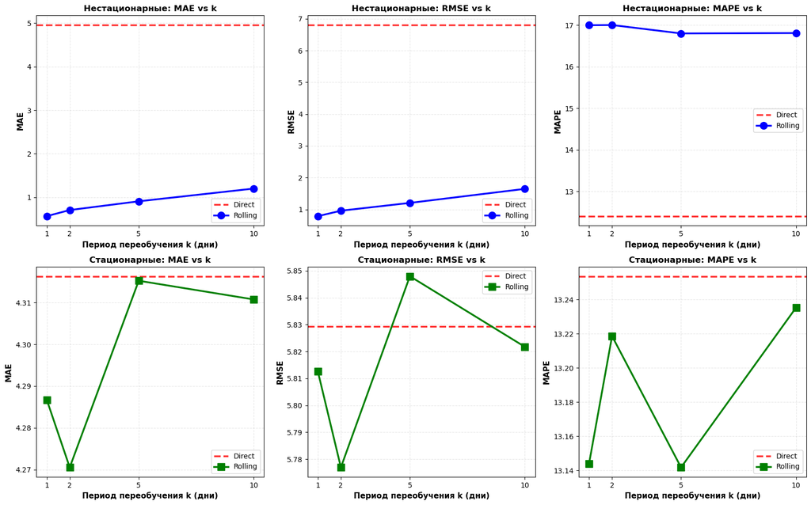

```python
fig, axes = plt.subplots(2, 3, figsize=(16, 10))

metrics = ['MAE', 'RMSE', 'MAPE']

# Нестационарные данные
for col, metric in enumerate(metrics):
    ax = axes[0, col]

    if metric == 'MAE':
        direct_val = mae_direct
    elif metric == 'RMSE':
        direct_val = rmse_direct
    else:
        direct_val = mape_direct

    # Горизонтальная линия для Direct
    ax.axhline(direct_val, color='red', linestyle='--', linewidth=2.5, label='Direct', alpha=0.8)

    # Линия для Rolling
    rolling_data = results_hyp2_nonstat_df[results_hyp2_nonstat_df['Strategy'] == 'Rolling']
    ax.plot(rolling_data['Period k'], rolling_data[metric],
            marker='o', color='blue', linewidth=2.5, markersize=10, label='Rolling')

    ax.set_xlabel('Период переобучения k (дни)', fontsize=11, fontweight='bold')
    ax.set_ylabel(metric, fontsize=11, fontweight='bold')
    ax.set_title(f'Нестационарные: {metric} vs k', fontsize=12, fontweight='bold')
    ax.legend(fontsize=10)
    ax.grid(True, alpha=0.3, linestyle='--')
    ax.set_xticks([1, 2, 5, 10])

# Стационарные данные
for col, metric in enumerate(metrics):
    ax = axes[1, col]

    if metric == 'MAE':
        direct_val = mae_direct_stat
    elif metric == 'RMSE':
        direct_val = rmse_direct_stat
    else:
        direct_val = mape_direct_stat

    # Горизонтальная линия для Direct
    ax.axhline(direct_val, color='red', linestyle='--', linewidth=2.5, label='Direct', alpha=0.8)

    # Линия для Rolling
    rolling_data = results_hyp2_stat_df[results_hyp2_stat_df['Strategy'] == 'Rolling']
    ax.plot(rolling_data['Period k'], rolling_data[metric],
            marker='s', color='green', linewidth=2.5, markersize=10, label='Rolling')

    ax.set_xlabel('Период переобучения k (дни)', fontsize=11, fontweight='bold')
    ax.set_ylabel(metric, fontsize=11, fontweight='bold')
    ax.set_title(f'Стационарные: {metric} vs k', fontsize=12, fontweight='bold')
    ax.legend(fontsize=10)
    ax.grid(True, alpha=0.3, linestyle='--')
    ax.set_xticks([1, 2, 5, 10])

plt.tight_layout()
plt.show()
```

Сравним время выполнения для различных моделей

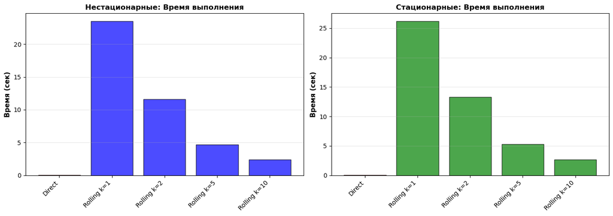

```python
fig, axes = plt.subplots(1, 2, figsize=(14, 5))

# Нестационарные данные
strategies_nonstat = results_hyp2_nonstat_df['Strategy'] + ' k=' + results_hyp2_nonstat_df['Period k'].astype(str)
strategies_nonstat = strategies_nonstat.replace('Direct k=-', 'Direct')

axes[0].bar(range(len(results_hyp2_nonstat_df)), results_hyp2_nonstat_df['Time (s)'],
            color=['red'] + ['blue']*4, alpha=0.7, edgecolor='black')
axes[0].set_xticks(range(len(results_hyp2_nonstat_df)))
axes[0].set_xticklabels(strategies_nonstat, rotation=45, ha='right')
axes[0].set_ylabel('Время (сек)', fontsize=11, fontweight='bold')
axes[0].set_title('Нестационарные: Время выполнения', fontsize=12, fontweight='bold')
axes[0].grid(True, alpha=0.3, axis='y')

# Стационарные данные
strategies_stat = results_hyp2_stat_df['Strategy'] + ' k=' + results_hyp2_stat_df['Period k'].astype(str)
strategies_stat = strategies_stat.replace('Direct k=-', 'Direct')

axes[1].bar(range(len(results_hyp2_stat_df)), results_hyp2_stat_df['Time (s)'],
            color=['red'] + ['green']*4, alpha=0.7, edgecolor='black')
axes[1].set_xticks(range(len(results_hyp2_stat_df)))
axes[1].set_xticklabels(strategies_stat, rotation=45, ha='right')
axes[1].set_ylabel('Время (сек)', fontsize=11, fontweight='bold')
axes[1].set_title('Стационарные: Время выполнения', fontsize=12, fontweight='bold')
axes[1].grid(True, alpha=0.3, axis='y')

plt.tight_layout()
plt.show()
```

Теперь построим график MAE по дням для различных k на нестационарных данных

```
Расчёт ошибок по дням:

Direct: 504 ошибок
  k=1... Средн. MAE = 0.5696
  k=2... Средн. MAE = 0.7094
  k=5... Средн. MAE = 0.9045
  k=10... Средн. MAE = 1.1987

================================================================================
```

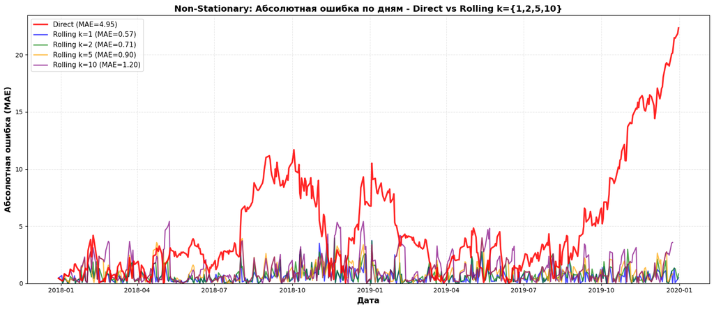

```python
def rolling_forecast_with_daily_errors(model_type, train_data, test_data, k):
    daily_errors = np.full(len(test_data), np.nan)
    current_train = train_data.copy()

    num_blocks = len(test_data) // k

    for block_idx in range(num_blocks):
        start_idx = block_idx * k
        end_idx = start_idx + k

        if model_type == 'HW':
            model = ExponentialSmoothing(current_train, trend='add', seasonal=None)
        else:
            model = ExponentialSmoothing(current_train, trend='add', seasonal=None)

        fitted = model.fit(optimized=True)
        forecast = fitted.forecast(steps=k)

        for i in range(k):
            if start_idx + i < len(test_data):
                pred_val = forecast.iloc[i] if hasattr(forecast, 'iloc') else forecast[i]
                real_val = test_data.iloc[start_idx + i]
                error = np.abs(real_val - pred_val)
                daily_errors[start_idx + i] = error

        real_block = test_data.iloc[start_idx:end_idx]
        current_train = pd.concat([current_train, real_block])

    return daily_errors


print("\nРасчёт ошибок по дням:\n")
direct_pred_values = np.asarray(pred_direct_nonstat).flatten()
test_values = np.asarray(test_nonstationary.values).flatten()
direct_errors_daily = np.abs(test_values - direct_pred_values)

print(f"Direct: {len(direct_errors_daily)} ошибок")

# Rolling ошибки для каждого k
rolling_errors_daily = {}

for k in [1, 2, 5, 10]:
    print(f"  k={k}...", end=' ', flush=True)
    errors = rolling_forecast_with_daily_errors('HW', train_nonstationary, test_nonstationary, k)
    rolling_errors_daily[k] = errors
    print(f"Средн. MAE = {np.nanmean(errors):.4f}")

print("\n" + "=" * 80)



fig, ax = plt.subplots(figsize=(16, 7))

# Direct (ЛИНИЯ по дням)
direct_mae = np.mean(direct_errors_daily)
ax.plot(test_nonstationary.index, direct_errors_daily,
        color='red', linewidth=2.5, alpha=0.85,
        label=f'Direct (MAE={direct_mae:.2f})', zorder=5)

# Rolling для каждого k
colors = ['blue', 'green', 'orange', 'purple']
for k, color in zip([1, 2, 5, 10], colors):
    errors = rolling_errors_daily[k]
    ax.plot(test_nonstationary.index, errors,
            label=f'Rolling k={k} (MAE={np.nanmean(errors):.2f})',
            color=color, linewidth=1.8, alpha=0.7, zorder=4)

ax.set_xlabel('Дата', fontsize=13, fontweight='bold')
ax.set_ylabel('Абсолютная ошибка (MAE)', fontsize=13, fontweight='bold')
ax.set_title('Non-Stationary: Абсолютная ошибка по дням - Direct vs Rolling k={1,2,5,10}',
             fontsize=14, fontweight='bold')
ax.legend(fontsize=11, loc='upper left')
ax.grid(True, alpha=0.3, linestyle='--')
ax.set_ylim(bottom=0)

plt.tight_layout()
plt.show()
```

По графику MAE vs Date мы можем увидеть, что когда происходит большое отклонения DirectPredict от Test, тогда другие прогнозы тоже дают пик, но намного меньшей длительности и величины. Из-за того что модель переобучается и подстраивается от резкие развороты рынка.

Теперь построим этот график для моделей на стационарных данных

```
Расчёт ошибок по дням:

Direct: 503 ошибок, MAE=4.3163
  k=1... Средн. MAE = 4.2868
  k=2... Средн. MAE = 4.2707
  k=5... Средн. MAE = 4.3158
  k=10... Средн. MAE = 4.3113
```

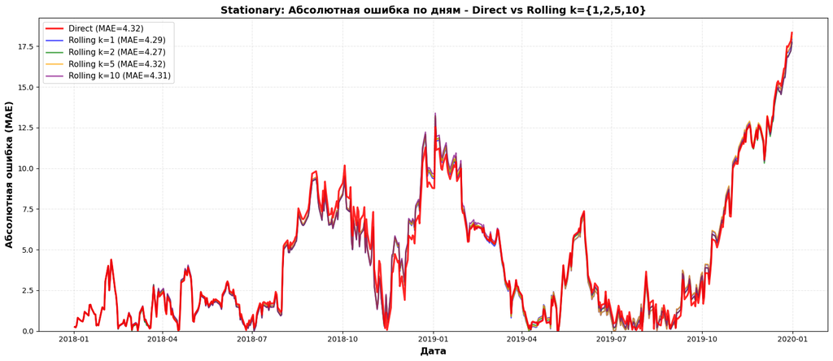

```python
def rolling_forecast_with_daily_errors_and_predictions(model_type, train_data, test_data, k):
    daily_predictions = np.full(len(test_data), np.nan)
    daily_errors = np.full(len(test_data), np.nan)
    current_train = train_data.copy()

    num_blocks = len(test_data) // k

    for block_idx in range(num_blocks):
        start_idx = block_idx * k
        end_idx = start_idx + k

        if model_type == 'HW':
            model = ExponentialSmoothing(current_train, trend='add', seasonal=None)
        else:
            model = ExponentialSmoothing(current_train, trend='add', seasonal=None)

        fitted = model.fit(optimized=True)
        forecast = fitted.forecast(steps=k)

        for i in range(k):
            if start_idx + i < len(test_data):
                pred_val = forecast.iloc[i] if hasattr(forecast, 'iloc') else forecast[i]
                real_val = test_data.iloc[start_idx + i]
                error = np.abs(real_val - pred_val)
                daily_predictions[start_idx + i] = pred_val
                daily_errors[start_idx + i] = error

        real_block = test_data.iloc[start_idx:end_idx]
        current_train = pd.concat([current_train, real_block])

    return daily_predictions, daily_errors

# ===== РАССЧИТЫВАЕМ ОШИБКИ ДЛЯ КАЖДОГО k (STATIONARY) =====

print("\nРасчёт ошибок по дням:\n")

# Direct ошибки ПО ДНЯМ
direct_pred_stat_values = np.asarray(pred_direct_stat_aligned).flatten()
test_stat_values = np.asarray(test_nonstationary_aligned.values).flatten()
direct_errors_stat_daily = np.abs(test_stat_values - direct_pred_stat_values)

print(f"Direct: {len(direct_errors_stat_daily)} ошибок, MAE={np.mean(direct_errors_stat_daily):.4f}")

# Rolling ошибки для каждого k (Stationary)
rolling_errors_stat_daily = {}

for k in [1, 2, 5, 10]:
    print(f"  k={k}...", end=' ', flush=True)

    # Получаем ПРОГНОЗЫ в log-returns
    pred_log_returns, _ = rolling_forecast_with_daily_errors_and_predictions(
        'HW', train_stationary, test_stationary, k
    )

    # Восстанавливаем цены из ПРОГНОЗОВ (не из ошибок!)
    pred_restored = restore_prices_from_log_returns(
        pd.Series(pred_log_returns, index=test_stationary.index[:len(pred_log_returns)]),
        train_nonstationary.iloc[-1]
    )

    # Берём только нужную длину
    pred_restored_aligned = pred_restored[:len(test_nonstationary_aligned)].values

    # Вычисляем ошибки между восстановленными ценами и реальными
    errors_stat = np.abs(test_stat_values - pred_restored_aligned)

    rolling_errors_stat_daily[k] = errors_stat
    print(f"Средн. MAE = {np.nanmean(errors_stat):.4f}")



fig, ax = plt.subplots(figsize=(16, 7))

# Direct
direct_mae_stat = np.mean(direct_errors_stat_daily)
ax.plot(test_nonstationary_aligned.index, direct_errors_stat_daily,
        color='red', linewidth=2.5, alpha=0.85,
        label=f'Direct (MAE={direct_mae_stat:.2f})', zorder=5)

# Rolling для каждого k
colors = ['blue', 'green', 'orange', 'purple']
for k, color in zip([1, 2, 5, 10], colors):
    errors = rolling_errors_stat_daily[k]
    ax.plot(test_nonstationary_aligned.index, errors,
            label=f'Rolling k={k} (MAE={np.nanmean(errors):.2f})',
            color=color, linewidth=1.8, alpha=0.7, zorder=4)

ax.set_xlabel('Дата', fontsize=13, fontweight='bold')
ax.set_ylabel('Абсолютная ошибка (MAE)', fontsize=13, fontweight='bold')
ax.set_title('Stationary: Абсолютная ошибка по дням - Direct vs Rolling k={1,2,5,10}',
             fontsize=14, fontweight='bold')
ax.legend(fontsize=11, loc='upper left')
ax.grid(True, alpha=0.3, linestyle='--')
ax.set_ylim(bottom=0)

plt.tight_layout()
plt.show()
```

Особенного влияния переобучение на значение MAE не оказывает. Видимо дело в том, что для стационарного ряда прямой прогноз, даёт значительно лучший результат на стационарных данных, но переобучение, основанное на этом ряду занчительно не улучшает прогноз.

Теперь график зависимости MAE от времени

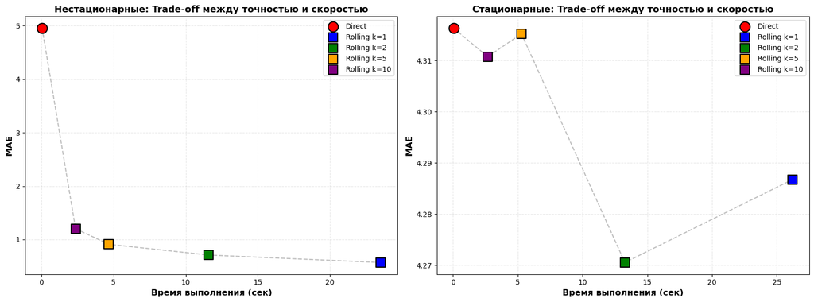

```python
fig, axes = plt.subplots(1, 2, figsize=(16, 6))

#  Нестационарные данные
ax = axes[0]

# СОРТИРУЕМ по времени
sorted_indices_nonstat = np.argsort(results_hyp2_nonstat_df['Time (s)'].values)
times_nonstat = results_hyp2_nonstat_df['Time (s)'].values[sorted_indices_nonstat]
maes_nonstat = results_hyp2_nonstat_df['MAE'].values[sorted_indices_nonstat]

# Соединяем точки линиями
ax.plot(times_nonstat, maes_nonstat, color='gray', linestyle='--', linewidth=1.5, alpha=0.5, zorder=1)

# Direct точка (находим индекс Direct в отсортированных данных)
direct_idx_nonstat = np.where(results_hyp2_nonstat_df['Strategy'] == 'Direct')[0][0]
direct_time_nonstat = results_hyp2_nonstat_df.loc[direct_idx_nonstat, 'Time (s)']
direct_mae_nonstat = results_hyp2_nonstat_df.loc[direct_idx_nonstat, 'MAE']

ax.scatter(direct_time_nonstat, direct_mae_nonstat, s=200, color='red', marker='o',
           label='Direct', zorder=5, edgecolor='black', linewidth=1.5)

# Rolling точки
colors = ['blue', 'green', 'orange', 'purple']
retraining_periods = [1, 2, 5, 10]

for k, color in zip(retraining_periods, colors):
    rolling_row = results_hyp2_nonstat_df[
        (results_hyp2_nonstat_df['Strategy'] == 'Rolling') &
        (results_hyp2_nonstat_df['Period k'] == k)
    ]
    if not rolling_row.empty:
        t = rolling_row['Time (s)'].values[0]
        m = rolling_row['MAE'].values[0]
        ax.scatter(t, m, s=150, color=color, marker='s', label=f'Rolling k={k}',
                   zorder=4, edgecolor='black', linewidth=1.5)

ax.set_xlabel('Время выполнения (сек)', fontsize=12, fontweight='bold')
ax.set_ylabel('MAE', fontsize=12, fontweight='bold')
ax.set_title('Нестационарные: Trade-off между точностью и скоростью', fontsize=13, fontweight='bold')
ax.legend(fontsize=10)
ax.grid(True, alpha=0.3, linestyle='--')

# Стационарные данные
ax = axes[1]

# СОРТИРУЕМ по времени
sorted_indices_stat = np.argsort(results_hyp2_stat_df['Time (s)'].values)
times_stat = results_hyp2_stat_df['Time (s)'].values[sorted_indices_stat]
maes_stat = results_hyp2_stat_df['MAE'].values[sorted_indices_stat]

# Соединяем точки линиями
ax.plot(times_stat, maes_stat, color='gray', linestyle='--', linewidth=1.5, alpha=0.5, zorder=1)

# Direct точка
direct_idx_stat = np.where(results_hyp2_stat_df['Strategy'] == 'Direct')[0][0]
direct_time_stat = results_hyp2_stat_df.loc[direct_idx_stat, 'Time (s)']
direct_mae_stat = results_hyp2_stat_df.loc[direct_idx_stat, 'MAE']

ax.scatter(direct_time_stat, direct_mae_stat, s=200, color='red', marker='o',
           label='Direct', zorder=5, edgecolor='black', linewidth=1.5)

# Rolling точки
for k, color in zip(retraining_periods, colors):
    rolling_row = results_hyp2_stat_df[
        (results_hyp2_stat_df['Strategy'] == 'Rolling') &
        (results_hyp2_stat_df['Period k'] == k)
    ]
    if not rolling_row.empty:
        t = rolling_row['Time (s)'].values[0]
        m = rolling_row['MAE'].values[0]
        ax.scatter(t, m, s=150, color=color, marker='s', label=f'Rolling k={k}',
                   zorder=4, edgecolor='black', linewidth=1.5)

ax.set_xlabel('Время выполнения (сек)', fontsize=12, fontweight='bold')
ax.set_ylabel('MAE', fontsize=12, fontweight='bold')
ax.set_title('Стационарные: Trade-off между точностью и скоростью', fontsize=13, fontweight='bold')
ax.legend(fontsize=10)
ax.grid(True, alpha=0.3, linestyle='--')

plt.tight_layout()
plt.show()
```

Теперь перейдём к итоговым выводам:

```python
print("=" * 80)
print("ИТОГОВЫЕ ВЫВОДЫ")
print("=" * 80)

print("\nГИПОТЕЗА 1: Влияние стационарности\n")

best_nonstat_row = results_df[results_df['Model'].str.contains('Нестац')].loc[
    results_df[results_df['Model'].str.contains('Нестац')]['MAE'].idxmin()
]
best_stat_row = results_df[results_df['Model'].str.contains('Стац')].loc[
    results_df[results_df['Model'].str.contains('Стац')]['MAE'].idxmin()
]

print(f"Лучшая нестационарная модель: {best_nonstat_row['Model']}")
print(f"  MAE: {best_nonstat_row['MAE']:.4f}, RMSE: {best_nonstat_row['RMSE']:.4f}, MAPE: {best_nonstat_row['MAPE']:.2f}%")

print(f"\nЛучшая стационарная модель: {best_stat_row['Model']}")
print(f"  MAE: {best_stat_row['MAE']:.4f}, RMSE: {best_stat_row['RMSE']:.4f}, MAPE: {best_stat_row['MAPE']:.2f}%")

improvement_h1 = ((best_nonstat_row['MAE'] - best_stat_row['MAE']) / best_nonstat_row['MAE']) * 100
print(f"\nУлучшение при использовании стационарного ряда: {improvement_h1:+.2f}%")

if improvement_h1 > 0:
    print("ГИПОТЕЗА 1 ПОДТВЕРЖДЕНА: Приведение к стационарности улучшает прогноз")
else:
    print("ГИПОТЕЗА 1 НЕ ПОДТВЕРЖДЕНА: Стационарность не улучшает прогноз")

print("\n" + "-" * 80)
print("\nГИПОТЕЗА 2: Влияние частоты переобучения\n")

best_nonstat_h2_row = results_hyp2_nonstat_df.loc[results_hyp2_nonstat_df['MAE'].idxmin()]
best_stat_h2_row = results_hyp2_stat_df.loc[results_hyp2_stat_df['MAE'].idxmin()]

print(f"Нестационарные данные:")
print(f"  Лучшая стратегия: {best_nonstat_h2_row['Strategy']} k={best_nonstat_h2_row['Period k']}")
print(f"  MAE: {best_nonstat_h2_row['MAE']:.4f}, Время: {best_nonstat_h2_row['Time (s)']:.2f}s")

print(f"\nСтационарные данные:")
print(f"  Лучшая стратегия: {best_stat_h2_row['Strategy']} k={best_stat_h2_row['Period k']}")
print(f"  MAE: {best_stat_h2_row['MAE']:.4f}, Время: {best_stat_h2_row['Time (s)']:.2f}s")

better_nonstat = best_nonstat_h2_row['Strategy'] == 'Rolling'
better_stat = best_stat_h2_row['Strategy'] == 'Rolling'

print(f"\nГипотеза 2 подтверждена?")
print(f"  Нестационарные: {'ДА' if better_nonstat else 'НЕТ'} (Rolling лучше Direct)")
print(f"  Стационарные: {'ДА' if better_stat else 'НЕТ'} (Rolling лучше Direct)")

if better_nonstat and better_stat:
    print("\nГИПОТЕЗА 2 ПОДТВЕРЖДЕНА: Периодическое переобучение превосходит прямой прогноз")
elif better_nonstat or better_stat:
    print("\nГИПОТЕЗА 2 ЧАСТИЧНО ПОДТВЕРЖДЕНА: Зависит от типа данных")
else:
    print("\nГИПОТЕЗА 2 НЕ ПОДТВЕРЖДЕНА: Прямой прогноз не хуже периодического переобучения")

print("\n" + "=" * 80)
```

```
================================================================================
ИТОГОВЫЕ ВЫВОДЫ
================================================================================

ГИПОТЕЗА 1: Влияние стационарности

Лучшая нестационарная модель: Holt-Winters (Нестац)
  MAE: 4.5915, RMSE: 5.6620, MAPE: 9.97%

Лучшая стационарная модель: Holt (Стац)
  MAE: 4.3163, RMSE: 5.8292, MAPE: 8.88%

Улучшение при использовании стационарного ряда: +5.99%
ГИПОТЕЗА 1 ПОДТВЕРЖДЕНА: Приведение к стационарности улучшает прогноз

--------------------------------------------------------------------------------

ГИПОТЕЗА 2: Влияние частоты переобучения

Нестационарные данные:
  Лучшая стратегия: Rolling k=1
  MAE: 0.5696, Время: 23.52s

Стационарные данные:
  Лучшая стратегия: Rolling k=2
  MAE: 4.2706, Время: 13.27s

Гипотеза 2 подтверждена?
  Нестационарные: ДА (Rolling лучше Direct)
  Стационарные: ДА (Rolling лучше Direct)

ГИПОТЕЗА 2 ПОДТВЕРЖДЕНА: Периодическое переобучение превосходит прямой прогноз

================================================================================
```